```python
# @title Načítanie súborov
# Import potrebných knižníc

import numpy as np
import pandas as pd
from scipy.optimize import linprog
import cvxpy as cp
import matplotlib.pyplot as plt

#Načítanie dát z github.com
!git clone https://github.com/TominkoTomas/TET_Lin_Prog.git
#Vytvorenie separovateľných dát
loading_separ_data = np.load('/content/TET_Lin_Prog/A01_separdata.npz')
separ_dataX = loading_separ_data["X"]
separ_dataY = loading_separ_data["Y"]
#Vytvorenie neseparovateľných dát
loading_nesepar_data = np.load('/content/TET_Lin_Prog/A01_nesepardata.npz')
nesepar_dataX = loading_nesepar_data["X"]
nesepar_dataY = loading_nesepar_data["Y"]
#Vytvorenie trénovacích a testovacích dát
test_file = pd.DataFrame(pd.read_excel('/content/TET_Lin_Prog/A01_test.xlsx'))
train_file = pd.DataFrame(pd.read_excel('/content/TET_Lin_Prog/A01_train.xlsx'))
```

```
Cloning into 'TET_Lin_Prog'...
remote: Enumerating objects: 6, done.
remote: Counting objects: 100% (6/6), done.
remote: Compressing objects: 100% (6/6), done.
remote: Total 6 (delta 0), reused 0 (delta 0), pack-reused 0
Receiving objects: 100% (6/6), 28.89 KiB | 739.00 KiB/s, done.
```

# **Predikovanie prežitia pasažierov Titanicu**

Na projekte pracovali: **Tomáš Varga**, **Erik Kolesár**, **Tadeáš Kaminský** : 2DAV
Podiel práce: $$\frac{1}{3}, \frac{1}{3}, \frac{1}{3}$$

## **Zadanie**

Jednou z typických úloh v strojovom učení je úloha klasifikácie dát. Dané sú dve množiny dát:

$X = \left \{ {x_{1}, . . . , x_{N}} \right \}⊆ R^{k}$  
$Y = \left \{ {y_{1}, . . . , y_{M}} \right \}⊆ R^{k}$

V lineárnej klasifikácii ide o nájdenie nadroviny danej vektorom *a* a skalárom *b*, ktorá dané dáta separuje, t.j. platí:

$ a^{T} x_{i} - b > 0, ∀i = 1, . . . , N$ (1)  
$ a^{T} y_{i} - b < 0, ∀i = 1, . . . , M$ (1)

Keďže tieto nerovnosti sú homogénne v *a*, *b* (t.j. možno ich násobiť ľubovoľným kladným číslom a nič sa nezmení), možno ich ekvivalentne vyjadriť ako:

$ a^{T} x_{i} - b \geq 1, ∀i = 1, . . . , N$ (2)  
$ a^{T} y_{i} - b \leq -1, ∀i = 1, . . . , M$ (2)

Takáto úloha sa dá riešiť ako úloha LP s premennými *a*, *b* a konštantnou (nulovou) účelovou funkciou.

## **Časť: A**

### **Zadanie**

Formulácia úlohy pre separovateľné dáta. Zdôvodnite, že nerovnosti (1) a (2) sú ekvivalentné.  
Naformulujte príslušnú úlohu prípustnosti LP (teda úlohu s konštantnou nulovou účelovou funkciou), ktorou nájdeme separujúcu nadrovinu.

### **Úvaha dôkazu**

Pre riešenie zadaného problému, bolo potrebné dve základné homogénne nerovnosti s ostrou nerovnosťou premeniť na nerovnosti, v ktorých sa nerovnosť zmení z ostrej na neostrú a pravá strana sa zmení z *0* na *1* a *-1*. Tento problém sme sa rozhodli riešiť spôsobom výberu najmenšieho možného ε, kde

$$ \varepsilon = min\left \{|a^{T} x_{i} - b|,| a^{T} y_{i} - b | \right \} \hspace{0.3cm} \forall x_{i} \in X \hspace{0.5cm},\forall y_{i} \in Y $$

teda ε je najmenšie možné číslo z množiny možných výsledkov, ktoré bude vždy kladné kvôli absolútnej hodnote. Tým, že dané číslo je najmenšie zo všetkých možných, nám zaručí to, že po vynásobení rovníc ε sa nestane to, že by pre ani jednu rovnicu neplatila nerovnosť, ktorú sa snažíme ukázať, čiže $$ \begin{align*} a^{T} x_{i} - b &\geq 1, ∀i = 1, . . . , N (2) \\ a^{T} y_{i} - b &\leq -1, ∀i = 1, . . . , M (2) \end{align*} $$ z pôvodných homogénnych nerovností sa teda stanú nami potrebné rovnice.

### **Riešenie**

Riešenie otázky ukázania ekvivalencie nerovnosti by mohlo byť formulované následným dôkazom.
**DÔKAZ:**
Chceme teda dokázať ekvivalenciu 2 výrazov: $$ \begin{align*} a^{T} x_{i} - b &> 0, \forall x_{i} \in X \hspace{1cm} a^{T} y_{i} - b < 0, \forall y_{i} \in Y \hspace{0.2cm} \\ \Leftrightarrow \hspace{0.2cm} \tilde{a}^{T} x_{i} - \tilde{b} &\geq 1, \forall x_{i} \in X \hspace{1cm} \tilde{a}^{T} y_{i} - \tilde{b} \leq -1, \forall y_{i} \in Y \end{align*} $$
Kde: $$ \hspace{0.1cm}\tilde{a} = \frac{1}{\varepsilon}a \hspace{0.3cm} \wedge \hspace{0.3cm} \tilde{b} = \frac{1}{\varepsilon}b \hspace{0.3cm} \wedge \hspace{0.3cm} \varepsilon = min\left \{|a^{T} x_{i} - b|,| a^{T} y_{i} - b | \right \}\hspace{0.3cm} \forall x_{i} \in X \hspace{0.5cm},\forall y_{i} \in Y $$

Postupnou úpravou dostávame teda: $$ \begin{align*} a^{T} x_{i} - b &> 0 \hspace{0.4cm}/ \hspace{0.1cm}*1/\varepsilon \\ a^{T} y_{i} - b &< 0 \hspace{0.4cm}/ \hspace{0.1cm}*1/\varepsilon \\ {(\frac{1}{\varepsilon}a)}^{T} x_{i} - {(\frac{1}{\varepsilon}b)} &> 0 \\ {(\frac{1}{\varepsilon}a)}^{T} y_{i} - {(\frac{1}{\varepsilon}b)} &< 0 \\ \end{align*} $$
Následne si môžeme všimnúť, že sme sa stále nezbavili ostrých nerovností. Tu nastáva najdôležitejšia časť našej úvahy a dôkazu, keďže sme zadefinovali ε ako najmenší možný výsledok, vieme našu pôvodnú úpravu spraviť znova a lepšie.

Čiže

$$ \begin{align*} a^{T} x_{i} - b \geq \varepsilon &> 0 \hspace{0.4cm}/ \hspace{0.1cm}*1/\varepsilon \\ a^{T} y_{i} - b \leq -\varepsilon &< 0 \hspace{0.4cm}/ \hspace{0.1cm}*1/\varepsilon \\ {(\frac{1}{\varepsilon}a)}^{T} x_{i} - {(\frac{1}{\varepsilon}b)} \geq 1 &> 0 \\ {(\frac{1}{\varepsilon}a)}^{T} y_{i} - {(\frac{1}{\varepsilon}b)} \leq -1 &< 0 \\ \end{align*} $$

Ako si môžeme všimnúť, využili sme spomenutú úvahu toho, že ε je najmenší možný výsledok. To sme aplikovali tým, že sme povedali, že všetky výsledky sú buď väčšie alebo rovné ako ε, ale menšie alebo rovné ako ε. Následným vynásobením 1/ε dostávame nami potrebné rovnice a to teda:

$$ {(\frac{1}{\varepsilon}a)}^{T} x_{i} - {(\frac{1}{\varepsilon}b)} \geq 1, \forall x_{i} \in X \hspace{1cm}{(\frac{1}{\varepsilon}a)}^{T} y_{i} - {(\frac{1}{\varepsilon}b)} \leq -1, \forall y_{i} \in Y $$

Čo je ekvivaletné s $$ \tilde{a}^{T} x_{i} - \tilde{b} \geq 1, \forall x_{i} \in X \hspace{1cm} \tilde{a}^{T} y_{i} - \tilde{b} \leq -1, \forall y_{i} \in Y \\ $$

Čo je to, čo sme chceli dokázať. Dalo by sa povedať, že sme nerovnice istým spôsobom naškálovali tak, aby z nich bolo možno spraviť úlohu lineárneho programovania a nasledne odstránili nerovnosti voči nule, kedže nerovnosti voči jednotke nestrácajú žiadnu informáciu. Nakoľko je ɛ najmenší možný výsledok.  
**FORMULÁCIA ÚLOHY LP:**

Z nasledujúcich rovníc sme schopní vyjadriť tieto rovnice v kompaktnom maticovom tvare a to nasledovne

**Rovnice:**
$$ \begin{align*} max &\hspace{0.3cm}0 \\ a^{T}x - b &\geq 1\\ -x^{T}a + b &\leq -1\\ \\ a^{T}y - b &\leq -1\\ y^{T}a - b &\leq -1\\ \end{align*}$$

**Kompaktný tvar:**

$$ max \hspace{0.3cm}0 \\ \left[ \begin{array}{ccc|c} &-x_{1}^{T}&& \\ &\vdots & & \mathbf{1}_N\\ & -x_{N}^{T} & & \\ \hline & y_{1}^{T} & & \\ & \vdots & & -\mathbf{1}_M \\ & y_{M}^{T} & & \end{array} \right] \times \begin{bmatrix} |\\ a\\ |\\ \hline b \end{bmatrix} \leq \begin{bmatrix} \\ -\mathbf{1}_N\\ \\ \hline\\ \\ -\mathbf{1}_M\\ \\ \end{bmatrix}$$
Je doležité si zároveň uvedomiť, že 0 učelová funkcia hovorí o tom, že každé riešenie úlohy, ktoré je prípustné je aj optimálne.

## **Časť: B**

**Úvod:**  
V tejto časti sme sa zamerali na praktickú implementáciu poznatkov získaných v predchádzajúcej časti (časť A) na dáta, pre ktoré sme schopní identifikovať separujúcu nadrovinu.

### **Kód**#

```
Rozmer matice X:(10, 2)
 Matica X:
[[ 3.62559865 -0.01923576]
 [ 2.88904303 -0.87906568]
 [ 2.16794246  1.43548134]
 [ 1.23243555 -3.96734699]
 [ 1.42664776 -1.91820866]
 [ 0.50631955 -4.24939729]
 [ 0.92201009 -1.99356241]
 [ 1.97789572  0.14352615]
 [ 1.21729767 -3.98394068]
 [-0.43823076 -1.14878334]]

Rozmer matice Y:(6, 2)
 Matica Y:
[[ 0.36527816  6.61396889]
 [-2.41065739 -0.63417022]
 [-0.33375006  1.60990644]
 [-0.92577213 -0.07170937]
 [ 0.55880824  5.2896235 ]
 [-3.31874272 -4.92182012]]


optimalne riesenie metody simplex je:
 [ 1.96279865 -0.96841489 -0.74765986]
```

```
optimalne riesenie metody interior-point je:
 [ 6.5625659  -2.92732566 -1.17945655]


optimalne riesenie metody highs-ds je:
 [ 1.96279865 -0.96841489 -0.74765986]


optimalne riesenie metody revised simplex je:
 [ 1.96279865 -0.96841489 -0.74765986]
```

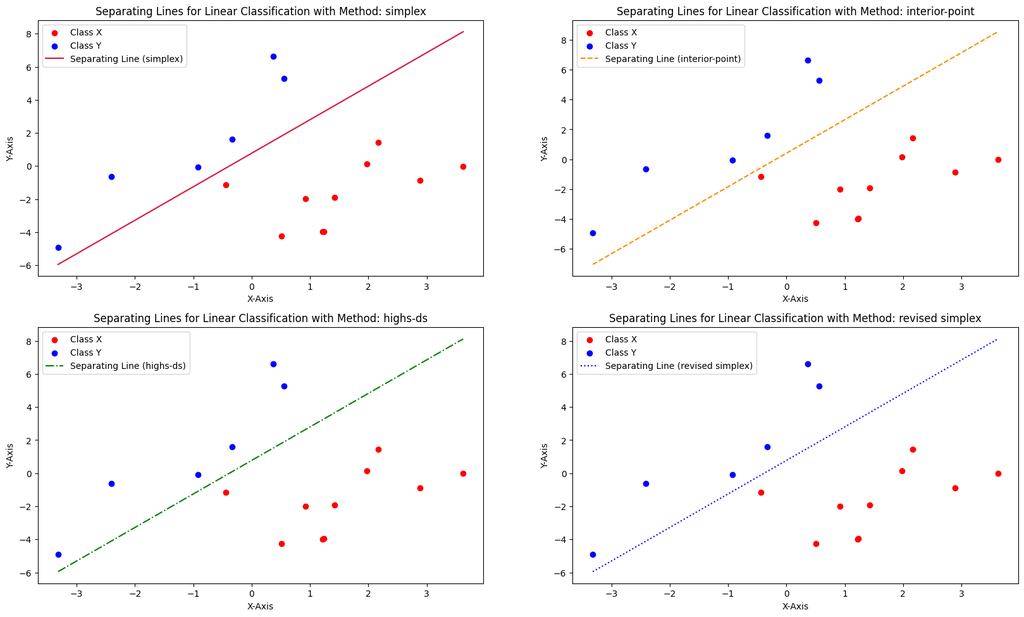

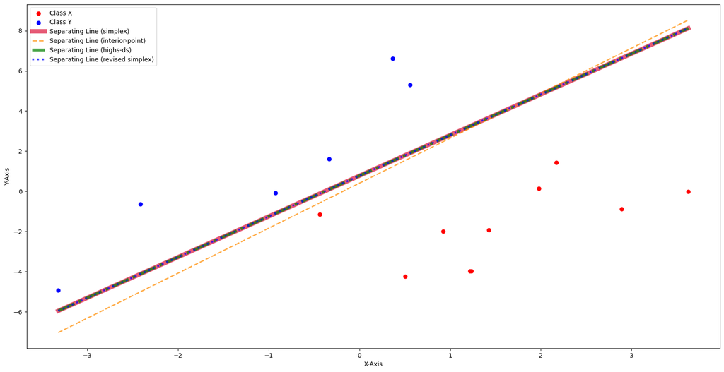

```python
matica_X = np.array(separ_dataX).T                                  # Úprava matice X
matica_Y = np.array(separ_dataY).T                                  # Úprava matice Y
N, k = matica_X.shape
M, g = matica_Y.shape
print(f'Rozmer matice X:{N,k}\n Matica X:')
print(matica_X)
print()
print(f'Rozmer matice Y:{M,g}\n Matica Y:')
print(matica_Y)
print()

new_separ_dataX = np.hstack((-matica_X,np.ones((N,1))))            # Pridanie -1 vektora s rozmermi N x 1
new_separ_dataY = np.hstack((matica_Y,-np.ones((M,1))))            # Pridanie -1 vektora s rozmermi M x 1

A = np.vstack((new_separ_dataX, new_separ_dataY))                  # Zkonštruoavanie finálnej matice A
b = np.array(-np.ones(N + M))                                      # Pravá strana nerovnosti
c = np.array(np.zeros(k + 1))                                      # Účelová funkcia

methods = ['simplex','interior-point','highs-ds','revised simplex']# Metódy použitia
colors  = ['crimson','darkorange','green','blue']                  # Farebna paleta pre separujuce priamky
type_of_line = ['-','--','-.',':']                                 # Typ vypisu separujucej nadroviny

fig, axs = plt.subplots(nrows=2, ncols=2, figsize=(20, 10))        # Priprava kreslenia plorov vedla seba

finall_result = []                                                 # Pomocne vypocty na neskôr

for i,method in enumerate(methods):
  x = 0
  y = 0
  if (i == 1 or i == 3):
    y = 1
  if(i == 2 or i == 3 ):
    x = 1

  # plt.figure(figsize=(10, 5))
  axs[x,y].scatter(matica_X[:, 0], matica_X[:, 1], label='Class X',c='red')          # Vykreslenie bodov matice X
  axs[x,y].scatter(matica_Y[:, 0], matica_Y[:, 1], label='Class Y',c = 'blue')       # Vykreslenie bodov matice Y
  result = linprog(c,A,b,method=method,bounds=(None,None))                           # Riešenie úlohy lineárneho programovania s danou metódou

  variable_a1 = result.x[0]                                      # Koeficient a1 pre separujúcu priamku
  variable_a2 = result.x[1]                                      # Koeficient a2 pre separujúcu priamku
  variable_b = result.x[-1]                                      # Koeficient b pre separujúcu priamku
  print()
  print(f'optimalne riesenie metody {method} je: \n {result.x}') # Vypis vysledku optimalizacie
  print()

  x_0 = min(np.min(matica_X[:, 0]),np.min(matica_Y[:, 0]))       # Nájdenie min z hodnot x pre maticu X a maticu Y (na zistenie hranic separujucej piarmky)
  x_1 = max(np.max(matica_X[:, 0]),np.max(matica_Y[:, 0]))       # Nájdenie max z hodnot x pre maticu X a maticu Y (na zistenie hranic separujucej piarmky)

  # Nakreslenie separujúcej priamky
  axs[x,y].plot([x_0,x_1],[(variable_b-variable_a1 * x_0)/variable_a2, (variable_b-variable_a1 * x_1)/variable_a2],label=f'Separating Line ({method})', linestyle=type_of_line[i],c = colors[i])

  finall_result.append(([x_0,x_1],[(variable_b-variable_a1 * x_0)/variable_a2, (variable_b-variable_a1 * x_1)/variable_a2])) #pridavanie priamok do zoznamu na neskorsie vyuzitie

  # Finálne grafické znázornenie
  axs[x,y].legend()
  axs[x,y].set_title(f'Separating Lines for Linear Classification with Method: {method}')
  axs[x,y].set_xlabel('X-Axis')
  axs[x,y].set_ylabel('Y-Axis')
fig.subplots_adjust(top=1)
plt.show()

##### Zakreslenie do jedneho grafu pre prehladnost
plt.figure(figsize=(20,10))
plt.scatter(matica_X[:, 0], matica_X[:, 1], label='Class X',c='red')          # Vykreslenie bodov matice X
plt.scatter(matica_Y[:, 0], matica_Y[:, 1], label='Class Y',c = 'blue')       # Vykreslenie bodov matice Y
plt.xlabel('X-Axis')
plt.ylabel('Y-Axis')
line_width = [7,2,4.5,3]
for i in range(len(methods)):
  plt.plot(finall_result[i][0],finall_result[i][1],label=f'Separating Line ({methods[i]})',linestyle=type_of_line[i],c = colors[i],lw = line_width[i],alpha = 0.7)  # Zakreslenie separujucich priamok do jedného grafu
plt.legend()
```

### **Postup a Záver**#

**Postup:**  
Proces začal transformáciou dát do vhodnej formy, kde sme vytvorili matice X a Y, reprezentujúce body z jednotlivých tried. Tieto matice sme potom upravili tak, aby bolo možné aplikovať lineárne programovanie.

Ďalej sme vytvorili nové matice a následne zostavili maticu A, ktorá zahŕňa všetky potrebné informácie o úlohe lineárneho programovania. Pravá strana nerovnice (b) a účelová funkcia (c) boli ďalej definované podľa potrebných parametrov.

Využili sme rôzne metódy lineárneho programovania, konkrétne 'simplex', 'interior-point', 'highs-ds' a 'revised simplex' pre riešenie úlohy. Pre každú z týchto metód sme získali optimálne riešenie, ktoré obsahuje koeficienty separujúcej priamky. Tieto koeficienty sme využili na vizualizáciu separujúcej priamky v rámci jednotlivých grafov pre každú metódu.

Grafy sme následne zobrazili v mriežke 2x2, kde každý graf predstavuje separujúcu priamku pre jednu z použitých metód. Body z matic X a Y sme farebne odlíšili a separujúce priamky sme zobrazili rôznymi farbami a typmi čiar. Na záver sme vytvorili jediný graf, ktorý zahŕňa všetky separujúce priamky pre lepšie porovnanie.  
**Záver:**  
Výsledky ukázali, že tri zo štyroch použitých metód (simplex, highs-ds, revised simplex) poskytujú rovnaké riešenie, čo poukazuje na podobný algoritmický prístup. Naopak, metóda interior-point poskytla odlišnú separujúcu priamku, naznačujúc odlišný spôsob jej výpočtu v porovnaní so simplexovými metódami. Tým sme demonštrovali aplikáciu teoretických konceptov v praxi a porovnali výsledky rôznych metód lineárneho programovania v kontexte našej úlohy klasifikácie.

## **Časť: C**

### **Zadanie**

Formulácia úlohy pre neseparovateľné dáta: Niektoré dátové množiny nie sú separovateľné, no napriek tomu by sme ich chceli aspoň približne oddeliť. To sa dá urobiť zavedením doplnkových nezáporných premenných $u \geq 0_N$ a $v \geq 0_M$ a "relaxovaním" pôvodných nerovností do tvaru:

$$ a^{T} x_{i} - b \geq 1 - u_{i}, \hspace{1cm} \forall i = 1, \ldots, N $$ $$ a^{T} y_{i} - b \leq -1 + v_{i}, \hspace{1cm} \forall i = 1, \ldots, M. $$

Tento systém nerovníc bude mať vždy riešenie aj pokiaľ dáta nie sú separovateľné – stačí zvoliť odchýlky *u*, *v* dostatočne veľké. Aby sme však získali rozumné riešenie, potrebujeme mať zložky *u*, *v* čo najmenšie možné, čo vedie na úlohu s účelovou funkciou:

$$ \text{min} \sum_{i=1}^{N} u_{i} + \sum_{j=1}^{M} v_{j}. $$

### **Riešenie**

Chceme formulovať úlohu lineárneho programovania, pričom máme tieto podmienky: $$ \begin{align*} a^{T} x_{i} - b &\geq 1 - u_i, \forall x_{i} \in X \hspace{1cm} a^{T} y_{i} - b \leq -1 + v_i, \forall y_{i} \in Y \hspace{0.2cm} \\ u_i &\geq 0, \forall i = 1 \ldots N \hspace{1cm} v_i \geq 0, \forall i = 1 \ldots M \end{align*} $$

Kde: $$ \hspace{0.1cm}u_i, v_i \text{ sú nezáporné odchýlkové premenné.} $$

Účelovú funkciu si môžeme jednoducho vyjadriť zo zadania: $$ \begin{align*} \text{min} \sum_{i=1}^N u_i + \sum_{j=1}^M v_j \end{align*} $$

Nerovnice si vyjadríme cez maticový tvar:

\begin{equation} \begin{bmatrix} -\mathbf{x}_1^T \\ \vdots \\ -\mathbf{x}_N^T \end{bmatrix} \cdot \mathbf{a} + b \cdot \mathbf{1}_N \leq \begin{bmatrix} -\mathbf{1} + \mathbf{u}_1 \\ \vdots \\ -\mathbf{1} + \mathbf{u}_N \end{bmatrix} \end{equation}

Túto metódu teraz použijeme v časti D.

## **Časť: D**

### **Zadanie**

Aplikujte túto metódu na matice X a Y zo súboru A01 nesepardata.npz. Výsledky graficky znázornite.

### **Riešenie**

Úlohu LP máme vyjadrenú v časti C, teraz si musíme úlohu graficky znázorniť, aby sme mohli vyvodiť záver.

```python
#Riešenie úlohy lineárneho programovania z časti C na neseparovateľných dátach
matica_X = np.array(nesepar_dataX).T #Vytvorenie matice X z neseparovateľných dát
matica_Y = np.array(nesepar_dataY).T #Vytvorenie matice Y z neseparovateľných dát
M, k = matica_Y.shape #Vytvorenie M a k ako rozmerov matice Y
N, k = matica_X.shape #Vytvorenie N a k ako rozmerov matice X

var_a = cp.Variable(k) #Vytvorenie premennej a
var_b = cp.Variable(1) #Vytvorenie premennej b
var_u = cp.Variable(N, nonneg=True) #Vytvorenie premennej u
var_v = cp.Variable(M, nonneg=True) #Vytvorenie premennej v

objective = cp.Minimize(cp.sum(var_u) + cp.sum(var_v)) #Účelová funkcia
constraints = [ #Obmedzenia úlohy LP
    matica_X @ var_a - var_b >= 1 - var_u,
    matica_Y @ var_a - var_b <= -1 + var_v
]

#Vyriešenie našej úlohy
problem = cp.Problem(objective, constraints)
problem.solve()
print(f'{problem.status=}')
print('Optimálna hodnota účelovej funkcie:', problem.value)

#Vypísanie hodnôt premenných
print('Zaokrúhlené riešenia:')
print('Premenná a:', var_a.value)
print('Premenná b:', var_b.value)
print('Premenná u:\n', var_u.value)
print('Premenná v:\n', var_v.value)
```

```
problem.status='optimal'
Optimálna hodnota účelovej funkcie: 5.9347796057554065
Zaokrúhlené riešenia:
Premenná a: [ 1.14909484 -1.1485449 ]
Premenná b: [-0.17100436]
Premenná u:
 [2.63654173e-11 1.03503911e-11 1.60410993e-11 1.71808265e-11
 2.46165986e-11 2.11706253e-11 9.41191606e-12 2.70740680e-11
 2.35509705e-11 2.44972987e-11 3.32649578e-11 2.13508897e-11
 2.01816983e-11 2.82260677e-11 1.68016766e-11 2.86700740e-11
 2.01488283e-11 2.66145619e-11 2.81920104e-11 1.90397669e-11
 2.47836992e-11 2.28415196e-11 1.26243201e-02 1.44943166e+00
 2.80454978e-11 2.37948567e-11 1.95532887e-09 1.99409976e-11
 3.45599501e-11 1.59588609e-11 2.10933775e-11 2.68204214e-11
 3.17521217e-11 1.77763281e-11 1.54667290e-11 2.27343849e-11
 1.91800353e-11 2.82737210e-11 1.40330211e-11 2.19434622e-11
 2.61536226e-11 2.47822616e-11 8.54909667e-12 1.25505644e-11
 1.90129863e-11 2.03710547e-11 2.38300257e-11 1.74163800e-11
 2.29540693e-11 1.47900156e-11]
Premenná v:
 [2.65621611e-11 1.71685244e-11 1.81492431e-11 2.72882511e-11
 2.78873279e-11 2.48558594e+00 2.48012902e-11 1.94544395e-11
 2.29456624e-11 2.01345253e-11 4.06010732e-11 1.98713768e+00
 1.99038118e-11 2.07600476e-11 2.47529974e-11 7.33457951e-10
 2.03919911e-11 2.20690687e-11 2.09985320e-11 3.01288128e-11
 4.91413919e-11 3.29053418e-11 2.54969373e-11 2.23933405e-11
 2.47946037e-11 1.77395151e-11 2.09582246e-11 1.35621907e-11
 2.21444957e-11 2.86767917e-11 1.57644856e-11 1.94485741e-11
 1.65358981e-11 1.37653270e-11 1.69039758e-11 2.27950991e-11
 2.04571729e-11 2.51286233e-11 2.81992421e-11 3.11724647e-11
 2.32025196e-11 1.28454774e-11 1.50468950e-11 2.44892071e-11
 2.44514127e-11 1.72332237e-11 2.20812810e-11 2.83947533e-11
 2.13212389e-11 2.94390854e-11]
```

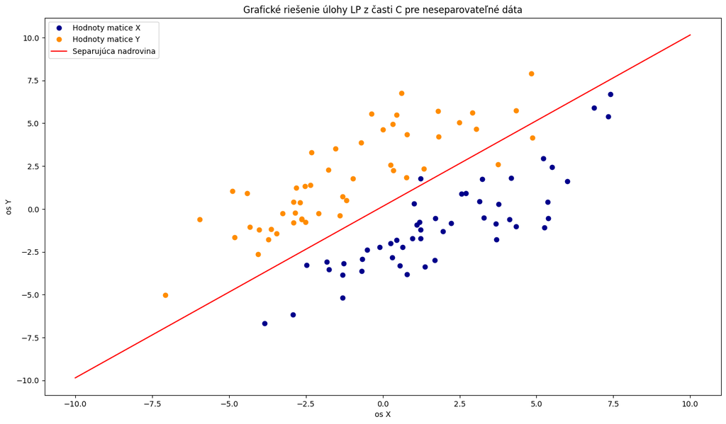

```python
#Vykreslenie úlohy LP z časti C
plt.figure(figsize=(16, 9))
plt.plot(*matica_X.T, 'o', c = 'darkblue', label = 'Hodnoty matice X')
plt.plot(*matica_Y.T, 'o', c = 'darkorange', label = 'Hodnoty matice Y')
plt.xlabel('os X')
plt.ylabel('os Y')
plt.title('Grafické riešenie úlohy LP z časti C pre neseparovateľné dáta')
#Vyjadrenie separujúcej nadroviny

x1 = np.linspace(-10, 10, 100000)
x2 = (var_b.value - var_a.value[0] * x1) / var_a.value[1]
plt.plot(x1, x2, c = 'red', label = 'Separujúca nadrovina')
#Vykreslenie samotného grafu

plt.legend()
plt.show()
```

### **Záver**

Po aplikovaní našej metódy a po grafickej analýze predložených dát môžeme konštatovať, že dve sady dát reprezentované maticou X (*tmavomodré body*) a maticou Y (*oranžové body*) nie sú lineárne separovateľné. Separujúca nadrovina, ktorá je znázornená červenou priamkou, neposkytuje dostatočne presné oddelenie týchto dvoch množín bodov. Ukazujú to dva body z matice Y a jeden bod z matice X. Môžeme preto povedať, že tieto dáta sú naozaj **neseparovateľné**.

## **Časť: E**

### **Zadanie**

Cieľom tejto úlohy je vytvoriť model na určenie presnosti správnej klasifikácie pasažierov Titanicu. Riešenie je postavené na dátach, kde hodnoty 0 a 1 v stĺpci 'Survived' predstavujú dve triedy – neprežitie a prežitie pasažiera. V tejto úlohe sú použité dáta 'Pclass' (trieda pasažiera), 'Sex' (pohlavie), 'SibSp' (počet príbuzných na palube) a 'Parch' (počet rodičov a detí na palube). Z dát sme zanedbali dátové atribúty 'name' (meno), 'age' (vek), 'ticket' (číslo lístka), 'fare' (cestovné), 'cabin' (číslo kabíny), 'emabarked' (nalodenie).

### **Spracovanie súborov**

Súbor A01 train.csv sme rozdelili na tabuľky train_X_0 a train_Y_0, podľa parametru 'survived' buď 0 alebo 1. Následne sme vyfiltrovali nepotrebné údaje a nechali si iba potrebné údaje zo zadania: Pclass, Sex, SibSp a Parch.

Filtrovanie sme aplikovali aj na súbor A01 train.csv určený na časť úlohy trénovanie.

```python
test_file_copy = test_file.copy(deep=True)
train_file_copy = train_file.copy(deep=True)

#Vyfiltrovanie množín X a Y
train_X_0 = train_file_copy[train_file_copy['survived'] == 0] # množina X
train_Y_1 = train_file_copy[train_file_copy['survived'] == 1] # množina Y

#Vyberieme si len potrebné údaje z trénovacej a testovacej tabuľky
train_file_X_0_final = train_X_0[['pclass', 'sex', 'sibsp', 'parch']]
train_file_Y_1_final = train_Y_1[['pclass', 'sex', 'sibsp', 'parch']]

test_file_final = test_file_copy[['survived','pclass', 'sex', 'sibsp', 'parch']]
```

### **Trénovanie**

Aplikovali sme model z časti C s úpravou premenných pre dáta zo súboru A01 train.csv.

```python
#Trénovanie
#Vytvorenie matíc XE a YE z trénovacích dát
matica_XE = train_file_X_0_final.values
matica_YE = train_file_Y_1_final.values

#Uloženie rozmerov matice
N, k = matica_XE.shape
M, k = matica_YE.shape

#Vytvorenie premenných
var_a = cp.Variable(k) #Vytvorenie premennej a
var_b = cp.Variable(1) #Vytvorenie premennej b
var_u = cp.Variable(N, nonneg=True) #Vytvorenie premennej u
var_v = cp.Variable(M, nonneg=True) #Vytvorenie premennej v

objective = cp.Minimize(cp.sum(var_u) + cp.sum(var_v)) #Účelová funkcia
constraints = [ #Obmedzenia úlohy LP
    matica_XE @ var_a - var_b + np.identity(N) @ var_u >= 1,
    -matica_YE @ var_a + var_b + np.identity(M) @ var_v >= 1
]

problem = cp.Problem(objective, constraints)
problem.solve()

optimal_a = var_a.value
optimal_b = var_b.value
# print('optimalne a:', end=' ')
# print(optimal_a,)
# print('optimalne b:', end=' ')
# print(optimal_b)
```

### **Testovanie**

Máme určit presnosť kvalifikácie "natrénovaného" modelu. To sme kontrolovali pre dáta zo súboru A01 test.csv.

Pasažier bol správne klasifikovaný, ak platila nerovnica:

$$ s_{i}\left ( \hat{a}^{T} z_{i} - \hat{b} \right )> 0 $$

```python
#Testovanie
maticaZE = test_file_final.values #Vytvorenie matice z testovacích dát
count_good_clasification = 0 #Počítadlo dobrej klasifikácie
count_bad_clasification = 0 #Počítadlo zlej klasifikácie

#Kontrola klasifikácie
for row in maticaZE:
  if row[0] == 0:
    s = -1
  else:
    s = 1
  value = (s)*(optimal_a.T @ row[1:] - optimal_b)  #Klasifikačná nerovnica
  if value > 0:
    count_good_clasification += 1
  else:
    count_bad_clasification += 1

# Kontrola výsledkov (stačí odkomentovať)

# print('dobre klasifikovany: ', end='')
# print(count_good_clasification)
# print('zle klasifikovany: ', end='')
# print(count_bad_clasification)
# print('celkovy pocet: ', count_bad_clasification + count_good_clasification)
# print('percetno spravne klasifikovanych = ', round(count_good_clasification/(count_good_clasification + count_bad_clasification)*100,2),'percent')
```

## **Časť: F**

### **Zadanie**

Pokračovanie časti C

- Účelová funkcia v časti C sa dá zapísať aj ako $\|u\|_1 + \|v\|_1$. Skúste experimentovať s inou voľbou účelovej funkcie, napríklad:

$$ \|u\|_{\infty} + \|v\|_{\infty} $$

$$ \max\{\|u\|_1, \|v\|_1\} $$

$$ \max\{\|u\|_{\infty}, \|v\|_{\infty}\} $$

$$ \max\left\{\frac{\|u\|_1}{\sqrt{k}}, \|u\|_{\infty}\right\} + \max\left\{\frac{\|v\|_1}{\sqrt{k}}, \|v\|_{\infty}\right\} $$

### **Riešenie**

```
problem.status='optimal'
Optimálna hodnota účelovej funkcie: 2.0000000005049774
Zaokrúhlené riešenia:
Premenná a: [ 3.40330575e-10 -4.27301805e-10]
Premenná b: [-0.0103295]
Premenná u:
 [0.9896705 0.9896705 0.9896705 0.9896705 0.9896705 0.9896705 0.9896705
 0.9896705 0.9896705 0.9896705 0.9896705 0.9896705 0.9896705 0.9896705
 0.9896705 0.9896705 0.9896705 0.9896705 0.9896705 0.9896705 0.9896705
 0.9896705 0.9896705 0.9896705 0.9896705 0.9896705 0.9896705 0.9896705
 0.9896705 0.9896705 0.9896705 0.9896705 0.9896705 0.9896705 0.9896705
 0.9896705 0.9896705 0.9896705 0.9896705 0.9896705 0.9896705 0.9896705
 0.9896705 0.9896705 0.9896705 0.9896705 0.9896705 0.9896705 0.9896705
 0.9896705]
Premenná v:
 [1.0103295 1.0103295 1.0103295 1.0103295 1.0103295 1.0103295 1.0103295
 1.0103295 1.0103295 1.0103295 1.0103295 1.0103295 1.0103295 1.0103295
 1.0103295 1.0103295 1.0103295 1.0103295 1.0103295 1.0103295 1.0103295
 1.0103295 1.0103295 1.0103295 1.0103295 1.0103295 1.0103295 1.0103295
 1.0103295 1.0103295 1.0103295 1.0103295 1.0103295 1.0103295 1.0103295
 1.0103295 1.0103295 1.0103295 1.0103295 1.0103295 1.0103295 1.0103295
 1.0103295 1.0103295 1.0103295 1.0103295 1.0103295 1.0103295 1.0103295
 1.0103295]
```

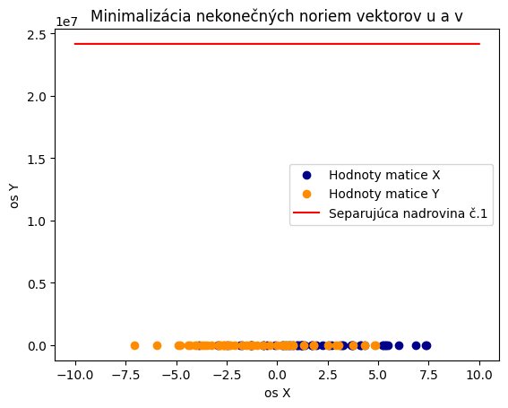

```python
#Minimalizácia nekonečných noriem vektorov u a v
matica_X = np.array(nesepar_dataX).T #Vytvorenie matice X z neseparovateľných dát
matica_Y = np.array(nesepar_dataY).T #Vytvorenie matice Y z neseparovateľných dát
M, k = matica_Y.shape #Vytvorenie M a k ako rozmerov matice Y
N, k = matica_X.shape #Vytvorenie N a k ako rozmerov matice X

var_a1 = cp.Variable(k) #Vytvorenie vektora a
var_b1 = cp.Variable(1) #Vytvorenie vektora b
var_u1 = cp.Variable(N, nonneg=True) #Vytvorenie vektora u
var_v1 = cp.Variable(M, nonneg=True) #Vytvorenie vektora v

objective = cp.Minimize(cp.norm(var_u1, 'inf') + cp.norm(var_v1, 'inf')) #Účelová funkcia
constraints = [ #Obmedzenia úlohy LP
    matica_X @ var_a1 - var_b1 >= 1 - var_u1,
    matica_Y @ var_a1 - var_b1 <= -1 + var_v1
]
#Vyriešenie našej úlohy
problem = cp.Problem(objective, constraints)
problem.solve()
print(f'{problem.status=}')
print('Optimálna hodnota účelovej funkcie:', problem.value)

#Vypísanie hodnôt premenných
print('Zaokrúhlené riešenia:')
print('Premenná a:', var_a1.value)
print('Premenná b:', var_b1.value)
print('Premenná u:\n', var_u1.value)
print('Premenná v:\n', var_v1.value)

# #Vykreslenie úlohy LP
plt.plot(*matica_X.T, 'o', c = 'darkblue', label = 'Hodnoty matice X')
plt.plot(*matica_Y.T, 'o', c = 'darkorange', label = 'Hodnoty matice Y')
plt.xlabel('os X')
plt.ylabel('os Y')
plt.title('Minimalizácia nekonečných noriem vektorov u a v')
#Vyjadrenie separujúcej nadroviny
x1_1 = np.linspace(-10, 10, 100000)
x2_1 = (var_b1.value - var_a1.value[0] * x1_1) / var_a1.value[1]
plt.plot(x1_1, x2_1, c = 'red', label = 'Separujúca nadrovina č.1')
#Vykreslenie samotného grafu
plt.legend()
plt.show()
```

```
problem.status='optimal'
Optimálna hodnota účelovej funkcie: 3.2977834942366733
Zaokrúhlené riešenia:
Premenná a: [ 0.9872884 -1.0593926]
Premenná b: [0.02137817]
Premenná u:
 [1.53827211e-12 1.74625843e-11 1.54276444e-12 1.53724691e-12
 1.53892714e-12 1.54010545e-12 1.56324416e-12 1.53866393e-12
 1.53881777e-12 1.53896625e-12 1.53955832e-12 1.54138022e-12
 1.58976049e-12 1.53856518e-12 1.54238696e-12 1.53904189e-12
 1.54031050e-12 1.53917721e-12 4.77148254e-01 1.54557116e-12
 1.53858116e-12 1.53923477e-12 8.06445725e-01 1.68313664e+00
 1.53947541e-12 1.71827766e-12 3.31052878e-01 1.54450195e-12
 1.53915267e-12 1.56072355e-12 1.54289104e-12 1.53861707e-12
 1.53900791e-12 1.54340248e-12 1.55589167e-12 1.54027172e-12
 1.54423943e-12 1.53888679e-12 1.55484388e-12 1.54114667e-12
 1.53820549e-12 1.53898307e-12 1.55409992e-12 1.54930930e-12
 1.54416642e-12 1.54581470e-12 1.53948664e-12 1.54690738e-12
 1.54016038e-12 1.54676724e-12]
Premenná v:
 [7.43119186e-13 7.45735152e-13 7.41085978e-13 8.44832574e-13
 7.42384574e-13 1.91925991e+00 7.42936004e-13 7.59367033e-13
 7.41779145e-13 7.44524625e-13 7.47034413e-13 1.37852358e+00
 7.44079550e-13 7.41661530e-13 7.42420138e-13 2.22566982e-12
 7.44535489e-13 7.65568597e-13 7.45021328e-13 7.42490043e-13
 7.93845114e-13 7.44078018e-13 7.42173944e-13 7.42451736e-13
 7.42171088e-13 7.40879851e-13 7.41336137e-13 7.49696025e-13
 7.40567316e-13 7.41841207e-13 7.40941445e-13 7.41013798e-13
 7.40204813e-13 7.42997323e-13 7.40193017e-13 7.40939676e-13
 7.41501102e-13 7.41048615e-13 7.43193009e-13 7.42611097e-13
 7.40511684e-13 7.43698631e-13 7.41427157e-13 7.42587744e-13
 7.40753193e-13 7.40293128e-13 7.41523562e-13 7.43698219e-13
 7.41733353e-13 7.42132205e-13]
```

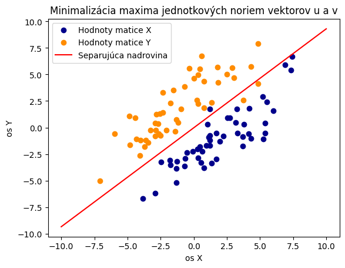

```python
#Minimalizácia maxima jednotkových noriem vektorov u a v
var_a2 = cp.Variable(k) #Vytvorenie vektora a
var_b2 = cp.Variable(1) #Vytvorenie vektora b
var_u2 = cp.Variable(N, nonneg=True) #Vytvorenie vektora u
var_v2 = cp.Variable(M, nonneg=True) #Vytvorenie vektora v

objective = cp.Minimize(cp.maximum(cp.norm(var_u2, 1), cp.norm(var_v2, 1))) #Účelová funkcia
constraints = [ #Obmedzenia úlohy LP
    matica_X @ var_a2 - var_b2 >= 1 - var_u2,
    matica_Y @ var_a2 - var_b2 <= -1 + var_v2
]

#Vyriešenie našej úlohy
problem = cp.Problem(objective, constraints)
problem.solve()
print(f'{problem.status=}')
print('Optimálna hodnota účelovej funkcie:', problem.value)

#Vypísanie hodnôt premenných
print('Zaokrúhlené riešenia:')
print('Premenná a:', var_a2.value)
print('Premenná b:', var_b2.value)
print('Premenná u:\n', var_u2.value)
print('Premenná v:\n', var_v2.value)

#Vykreslenie úlohy LP
plt.plot(*matica_X.T, 'o', c = 'darkblue', label = 'Hodnoty matice X')
plt.plot(*matica_Y.T, 'o', c = 'darkorange', label = 'Hodnoty matice Y')
plt.xlabel('os X')
plt.ylabel('os Y')
plt.title('Minimalizácia maxima jednotkových noriem vektorov u a v')
#Vyjadrenie separujúcej nadroviny
x1_2 = np.linspace(-10, 10, 100000)
x2_2 = (var_b2.value - var_a2.value[0] * x1_2) / var_a2.value[1]
plt.plot(x1_2, x2_2, c = 'red', label = 'Separujúca nadrovina')
#Vykreslenie samotného grafu
plt.legend()
plt.show()
```

```
problem.status='optimal'
Optimálna hodnota účelovej funkcie: 1.0000000000382203
Zaokrúhlené riešenia:
Premenná a: [ 5.14393848e-11 -6.38741663e-11]
Premenná b: [-1.15602562e-11]
Premenná u:
 [1. 1. 1. 1. 1. 1. 1. 1. 1. 1. 1. 1. 1. 1. 1. 1. 1. 1. 1. 1. 1. 1. 1. 1.
 1. 1. 1. 1. 1. 1. 1. 1. 1. 1. 1. 1. 1. 1. 1. 1. 1. 1. 1. 1. 1. 1. 1. 1.
 1. 1.]
Premenná v:
 [1. 1. 1. 1. 1. 1. 1. 1. 1. 1. 1. 1. 1. 1. 1. 1. 1. 1. 1. 1. 1. 1. 1. 1.
 1. 1. 1. 1. 1. 1. 1. 1. 1. 1. 1. 1. 1. 1. 1. 1. 1. 1. 1. 1. 1. 1. 1. 1.
 1. 1.]
```

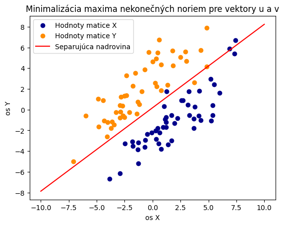

```python
#Minimalizácia maxima nekonečných noriem pre vektory u a v
var_a3 = cp.Variable(k) #Vytvorenie vektora a
var_b3 = cp.Variable(1) #Vytvorenie vektora b
var_u3 = cp.Variable(N, nonneg=True) #Vytvorenie vektora u
var_v3 = cp.Variable(M, nonneg=True) #Vytvorenie vektora v

objective = cp.Minimize(cp.maximum(cp.norm(var_u3, 'inf'), cp.norm(var_v3, 'inf'))) #Účelová funkcia
constraints = [ #Obmedzenia úlohy LP
    matica_X @ var_a3 - var_b3 >= 1 - var_u3,
    matica_Y @ var_a3 - var_b3 <= -1 + var_v3
]
#Vyriešenie nášej úlohy
problem = cp.Problem(objective, constraints)
problem.solve()
print(f'{problem.status=}')
print('Optimálna hodnota účelovej funkcie:', problem.value)

#Vypísanie hodnôt premenných
print('Zaokrúhlené riešenia:')
print('Premenná a:', var_a3.value)
print('Premenná b:', var_b3.value)
print('Premenná u:\n', var_u3.value)
print('Premenná v:\n', var_v3.value)

#Vykreslenie úlohy LP
plt.plot(*matica_X.T, 'o', c = 'darkblue', label = 'Hodnoty matice X')
plt.plot(*matica_Y.T, 'o', c = 'darkorange', label = 'Hodnoty matice Y')
plt.xlabel('os X')
plt.ylabel('os Y')
plt.title('Minimalizácia maxima nekonečných noriem pre vektory u a v')
#Vyjadrenie separujúcej nadroviny
x1_3 = np.linspace(-10, 10, 100000)
x2_3 = (var_b3.value - var_a3.value[0] * x1_3) / var_a3.value[1]
plt.plot(x1_3, x2_3, c = 'red', label = 'Separujúca nadrovina')
#Vykreslenie samotného grafu
plt.legend()
plt.show()
```

```python
#Minimalizácia súčtu dvoch maxím
var_a4 = cp.Variable(k) #Vytvorenie premennej a
var_b4 = cp.Variable(1) #Vytvorenie premennej b
var_u4 = cp.Variable(N, nonneg=True) #Vytvorenie premennej u
var_v4 = cp.Variable(M, nonneg=True) #Vytvorenie premennej v

objective = cp.Minimize( #Účelová funkcia
    cp.maximum(cp.norm(var_u4, 1)/cp.sqrt(k), cp.norm(var_u4, 'inf')) +
    cp.maximum(cp.norm(var_v4, 1)/cp.sqrt(k), cp.norm(var_v4, 'inf'))
)
constraints = [ #Obmedzenia úlohy LP
    matica_X @ var_a4 - var_b4 >= 1 - var_u4,
    matica_Y @ var_a4 - var_b4 <= -1 + var_v4
]

#Vyriešenie nášej úlohy
problem = cp.Problem(objective, constraints)
problem.solve()
print(f'{problem.status=}')
print('Optimálna hodnota účelovej funkcie:', problem.value)

#Vypísanie hodnôt premenných
print('Zaokrúhlené riešenia:')
print('Premenná a:', var_a4.value)
print('Premenná b:', var_b4.value)
print('Premenná u:\n', var_u4.value)
print('Premenná v:\n', var_v4.value)

#Vykreslenie úlohy LP
plt.plot(*matica_X.T, 'o', c = 'darkblue', label = 'Hodnoty matice X')
plt.plot(*matica_Y.T, 'o', c = 'darkorange', label = 'Hodnoty matice Y')
plt.xlabel('os X')
plt.ylabel('os Y')
plt.title('Minimalizácia súčtu dvoch maxím')
#Vyjadrenie separujúcej nadroviny
x1_4 = np.linspace(-10, 10, 100000)
x2_4 = (var_b4.value - var_a4.value[0] * x1_4) / var_a4.value[1]
plt.plot(x1_4, x2_4, c = 'red', label = 'Separujúca nadrovina')
#Vykreslenie samotného grafu
plt.legend()
plt.show()
```

[output not shown]

```python
#Vykreslenie všetkých grafov do jedného grafu
plt.plot(*matica_X.T, 'o', c = 'darkblue', label = 'Hodnoty matice X')
plt.plot(*matica_Y.T, 'o', c = 'darkorange', label = 'Hodnoty matice Y')
plt.xlabel('os X')
plt.ylabel('os Y')
plt.title('Zobrazenie všetkých separujúcich nadrovín do jedného grafu')

#Prvý graf bohužiaľ neukazuje pekné hodnoty
# x1_1 = np.linspace(-10, 10, 100000)
# x2_1 = (var_b1.value - var_a1.value[0] * x1_1) / var_a1.value[1]
# plt.plot(x1_1, x2_1, c = 'red', label = 'Separujúca nadrovina č.1')

#Druhý graf
x1_2 = np.linspace(-10, 10, 100000)
x2_2 = (var_b2.value - var_a2.value[0] * x1_2) / var_a2.value[1]
plt.plot(x1_2, x2_2, c = 'green', label = 'Separujúca nadrovina č.2')

#Tretí graf
x1_3 = np.linspace(-10, 10, 100000)
x2_3 = (var_b3.value - var_a3.value[0] * x1_3) / var_a3.value[1]
plt.plot(x1_3, x2_3, c = 'lightblue', label = 'Separujúca nadrovina č.3')

#Štvrtý graf
x1_4 = np.linspace(-10, 10, 100000)
x2_4 = (var_b4.value - var_a4.value[0] * x1_4) / var_a4.value[1]
plt.plot(x1_4, x2_4, c = 'pink', label = 'Separujúca nadrovina č.4')

#Vykreslenie samotného grafu
plt.legend()
plt.show()
```

[output not shown]

### **Záver**

Účelová funkcia, ktorá minimalizuje nekonečné normy premenných *u* a *v*, neukazuje podobné výsledky ako účelová funkcia v časti C. Je to spôsobené nízkymi hodnotami vektora *a* a rovnakými hodnotami vo vektoroch *u* a *v*, kde sú výsledné hodnoty blízke 1.

Zvyšné grafy ukazujú rovnaké výsledky, kde sa mierne zmenil sklon separujúcich nadrovín. Vždy však vieme nájsť aspoň jeden bod z matice X a jeden bod z matice Y, ktoré separáciu dát pokazia. To nám však nevadí, pretože dáta v množinách X a Y sú neseparovateľné, čo sa v grafe potvrdilo.